# 核心心律失常诊断错误/缺失 — 子集细化分析

基于宁波心电图数据库专家审阅数据（去重后 613 例主分析集）

Author

数据分析（AI 辅助）

Published

July 30, 2026

# 1 摘要

本报告针对宁波心电图数据库中被标记为「类型01：核心心律失常诊断错误或缺失」的病例子集，在已发表的主数据集 613 例总体判准率/不准确率/漏标率/误标率之外，进一步拆解该子集的**错误子类型、病种分布、共现结构、严重程度与归因**，并以 PTB-XL 双阅数据作为外部对照，为质控改进提供数据支撑。

> **数据一致性核查（重要）**：`偏差类型统计汇总` 表报告「类型01 含 = 170 / 纯 = 45」，但按 `明细数据` 逐例枚举「核心心律失常」专属短语复核，实际为 **含 = 125 / 纯 = 37**。本报告所有可复现计算均以可逐例枚举的明细数据为准（含 = 125），并在正文标注与汇总表的差异；若采用汇总表口径（170），各子集占比按同比例放大，但子集*内部*率不受影响。

# 2 1 数据与方法

## 2.1 1.1 数据源

- **主分析集**：`去重后_宁波合并_完整7.29.xlsx`，623 条去重记录 → 剔除 10 条未记录最终判定 = **613 例**（准确 274 / 不准确 339 / 未判定 10）。
- **偏差分类明细**：`宁波诊断不准确病例-诊断偏差分类.xlsx` 之 `明细数据` 表，364 例不准确病例 × 11 类偏差的多标签标注（一行一例，偏差类型以「、」连接）。
- **PTB-XL 外部对照**：`PTB-XL合并-7.28.xlsx`，101 对由 annotator 5 与 8 独立双阅的 ECG。

## 2.2 1.2 子集定义

| 子集 | 定义 | 本报告采用 n |
| --- | --- | --- |
| ① 含类型01 | 偏差类型含「核心心律失常诊断错误或缺失」 | **125**（汇总表口径 170） |
| ② 纯类型01 | 偏差类型仅有「核心心律失常诊断错误或缺失」 | **37**（汇总表口径 45） |
| ③ A/B/C/D 子类 | 子集①内按错误子型拆分 | 见 §3 |
| ④ 按病种 | 子集①内按真值核心心律失常病种拆分 | 见 §4 |

## 2.3 1.3 指标与错误子型定义

**四项总体率**（沿用主报告口径，于子集内重算）：

- 判准率 = 子集内判准例 / n（类型01子集定义上 100% 不准确，故此处同时报告其对 613 主集的占比）
- 不准确率 = 子集内不准确例 / n
- **漏标率** = 真值核心心律失常「临床等价族」在原始标注中**完全缺失**的病例占比（对应 A类 / 混合类）
- **误标率** = 原始标注含「临床等价族」误判/多余（含亚型混淆与多余核心）的病例占比（对应 B类 / D类）

**A/B/C/D 子类推导规则**（透明、可复现，基于 `combo_pattern_cn` 原始 vs `correctLabel` 真值）：

1. 将中文诊断名映射到「具体概念 + 临床等价族」两层（AF/AFL 同族、SVT 各亚型同族、各 AVB 分级按族归并等）。
2. `orig_fams` = 原始标注核心族集合；`true_fams` = 真值核心族集合。
3. **A类 完全缺失**：`true_fams` 中至少一族在 `orig_fams` 中不存在。
4. **B类 类型混淆**：两族集合相等，但同族内具体亚型不一致（如原始「心房扑动」/真值「心房颤动」）。
5. **C类 缺失+误标混合**：同时存在缺失族与多余族。
6. **D类 误标/表述不规范**：原始多出真值不含的核心族，或真值无核心族而被误标为核心错误。

> 说明：用户框架中的 C类「主次不分」与 D类「表述不规范」在结构化字段上难以自动区分，本报告将二者合并计入 D（误标/其他），并在 §7 归因中单列「主次/表述」需人工复核的提示。

## 2.4 1.4 统计学方法

- 比例均附 **Wilson 95% 置信区间**（小样本稳健）。
- 子集间比较（类型01 vs 非类型01 不准确病例）用 **Fisher 精确检验** + 优势比 OR（期望频数常 <5，不依赖 χ²）。
- 11 类偏差共现用 **Jaccard 系数**矩阵刻画。
- 算法层归因所需自动分析输出（MIMIC/机器初读）本研究未含，相关结论以「可获取数据信号」为限并明确标注缺口。

```r
# ---------- 读取数据 ----------
SRC_DIR <- "/Users/zengzhechun/SynologyDrive/工作/数据分析项目/心电图大模型/诊断标签准确性验证论文/01_数据/专家审阅/2026-07-29补充后数据"
DEV <- file.path(SRC_DIR, "宁波诊断不准确病例-诊断偏差分类.xlsx")
MAIN_XLSX <- file.path(SRC_DIR, "去重后_宁波合并_完整7.29.xlsx")
PTBXL <- file.path(SRC_DIR, "PTB-XL合并-7.28.xlsx")

det <- read_excel(DEV, sheet = "明细数据")
summ <- read_excel(DEV, sheet = "偏差类型统计汇总")
main <- read_excel(MAIN_XLSX, sheet = 1)

# 主集口径（与 v15 一致）
n_main <- nrow(main)            # 623 去重
n_acc  <- sum(main$conclusionChoice == "准确", na.rm = TRUE)   # 274
n_inacc <- sum(main$conclusionChoice == "不准确", na.rm = TRUE) # 339
n_und <- sum(is.na(main$conclusionChoice))                      # 10
```

```r
# ---------- 概念/族 映射 ----------
classify_cn <- function(name) {
  n <- trimws(as.character(name))
  if (grepl("心房颤动|房颤", n)) return(c("AFIB", "AF"))
  if (grepl("心房扑动|房扑", n)) return(c("AFL", "AF"))
  if (grepl("室上性心动过速|室上速|房性心动过速|房室折返|房室结折返|阵发性室上", n)) return(c("SVT", "SVT"))
  if (grepl("室性心动过速|室速", n)) return(c("VT", "VT"))
  if (grepl("心室颤动|室颤", n)) return(c("VF", "VF"))
  if (grepl("三度房室|高度房室|二度房室|II度房室|2度房室", n)) return(c("AVB_h", "AVB_h"))
  if (grepl("一度房室", n)) return(c("AVB_1", "AVB_1"))
  if (grepl("病态窦房结|病窦|窦房结", n)) return(c("SSS", "SSS"))
  if (grepl("室性早搏|室早", n)) return(c("PVC", "PVC"))
  if (grepl("房性早搏|房早", n)) return(c("PAC", "PAC"))
  if (grepl("右束支|左束支|束支传导", n)) return(c("BBB", "BBB"))
  if (grepl("窦性心动过缓", n)) return(c("SB", "SB"))
  if (grepl("窦性心律不齐", n)) return(c("SA", "SA"))
  if (grepl("起搏", n)) return(c("PM", "PM"))
  return(c(NA_character_, NA_character_))
}

parse_labels <- function(text) {
  if (is.na(text) || text == "") return(data.frame(spec = character(0), fam = character(0)))
  # combo_pattern_cn: "AF(心房扑动) + AVB(房室传导阻滞)"；correctLabel: "心房颤动\nT波改变"
  if (grepl("\\+", text)) {
    toks <- unlist(strsplit(text, "\\+"))
    specs <- fams <- character(0)
    for (t in toks) {
      m <- regmatches(t, regexpr("\\(([^)]+)\\)", t))
      cn <- ifelse(length(m) > 0, sub("\\(([^)]+)\\)", "\\1", m), trimws(t))
      r <- classify_cn(cn)
      if (!is.na(r[1])) { specs <- c(specs, r[1]); fams <- c(fams, r[2]) }
    }
    return(data.frame(spec = specs, fam = fams))
  } else {
    toks <- unlist(strsplit(text, "\n"))
    specs <- fams <- character(0)
    for (t in toks) {
      r <- classify_cn(t)
      if (!is.na(r[1])) { specs <- c(specs, r[1]); fams <- c(fams, r[2]) }
    }
    return(data.frame(spec = specs, fam = fams))
  }
}

# 对单行判定 A/B/C/D
classify_case <- function(combo_cn, correct) {
  o <- parse_labels(combo_cn); t <- parse_labels(correct)
  of <- unique(o$fam); tf <- unique(t$fam)
  if (length(of) == 0 && length(tf) == 0) return("NA_none")
  if (length(tf) == 0) return("D")          # 真值无核心族却被标为核心错误
  missed <- setdiff(tf, of)
  spurious <- setdiff(of, tf)
  if (length(missed) > 0 && length(spurious) > 0) return("C")
  if (length(missed) > 0) return("A")
  if (length(spurious) > 0) return("D")
  # 族相同，查亚型
  for (f in tf) {
    os <- o$spec[o$fam == f]; ts <- t$spec[t$fam == f]
    if (any(os != ts)) return("B")
  }
  return("B")  # 族相同且无亚型差异却仍被标为核心错误 -> 归类 B（含主次/表述，需人工）
}
```

```r
# ---------- 构建 type-01 子集 ----------
det <- det %>% mutate(
  is_t1 = grepl("核心心律失常", `偏差类型`),
  types = strsplit(`偏差类型`, "、")
)
t1 <- det %>% filter(is_t1)
n_t1 <- nrow(t1)                 # 125
# 纯类型01
pure_ids <- t1 %>% group_by(annotation_id) %>% summarise(
  only = all(sapply(types, function(v) length(v) == 1 && grepl("核心心律失常", v[1])))
)
n_pure <- sum(pure_ids$only)     # 37

# 先对 t1 计算 A/B/C/D 类型列（classify_case 需 combo_pattern_cn 与 correctLabel）
t1 <- t1 %>% mutate(
  abcd = mapply(classify_case, combo_pattern_cn, correctLabel)
)

# 全 125 例的 A/B/C/D 计数
abcd_tab <- t1 %>% count(abcd) %>% arrange(abcd)
abcd_n <- setNames(abcd_tab$n, abcd_tab$abcd)
# unname() 是关键：abcd_n 为命名向量，ifelse 会把名字 "A"/"C" 带入 wilson 的 p 分量，
# 使其返回名变为 "p.A" 而导致 miss_rate["p"] 取 NA（lo/hi 无名字故正常）。
A <- unname(ifelse(is.na(abcd_n["A"]), 0, abcd_n["A"]))
B <- unname(ifelse(is.na(abcd_n["B"]), 0, abcd_n["B"]))
C <- unname(ifelse(is.na(abcd_n["C"]), 0, abcd_n["C"]))
D <- unname(ifelse(is.na(abcd_n["D"]), 0, abcd_n["D"]))
miss_rate <- wilson(A + C, n_t1)     # 漏标率 = A + C
false_rate <- wilson(B + D, n_t1)    # 误标率 = B + D

# 纯子集需在 pure 病例内重算 A/B/C/D（不能直接用全 125 例的 A+C 除以 37，否则 >100%）
t1_pure <- t1 %>% filter(annotation_id %in% pure_ids$annotation_id[pure_ids$only])
abcd_p <- t1_pure %>% count(abcd) %>% arrange(abcd)
abcd_pn <- setNames(abcd_p$n, abcd_p$abcd)
A_p <- unname(ifelse(is.na(abcd_pn["A"]), 0, abcd_pn["A"]))
B_p <- unname(ifelse(is.na(abcd_pn["B"]), 0, abcd_pn["B"]))
C_p <- unname(ifelse(is.na(abcd_pn["C"]), 0, abcd_pn["C"]))
D_p <- unname(ifelse(is.na(abcd_pn["D"]), 0, abcd_pn["D"]))
```

# 3 2 子集总体四率

```r
# 对所有 364 例不准确病例跑同一分类器，作为对照基线
det_all <- det %>% mutate(abcd_all = mapply(classify_case, combo_pattern_cn, correctLabel))
base_A <- sum(det_all$abcd_all == "A", na.rm = TRUE)
base_B <- sum(det_all$abcd_all == "B", na.rm = TRUE)
base_C <- sum(det_all$abcd_all == "C", na.rm = TRUE)
base_D <- sum(det_all$abcd_all == "D", na.rm = TRUE)
base_n <- nrow(det_all)
base_miss <- wilson(base_A + base_C, base_n)
base_false <- wilson(base_B + base_D, base_n)

# 类型01 vs 非类型01 不准确：误标率 Fisher/OR
non_t1 <- det_all %>% filter(!is_t1)
or_mat <- matrix(c(A + C, B + D,
                   sum(non_t1$abcd_all == "A", na.rm = TRUE) + sum(non_t1$abcd_all == "C", na.rm = TRUE),
                   sum(non_t1$abcd_all == "B", na.rm = TRUE) + sum(non_t1$abcd_all == "D", na.rm = TRUE)),
                 nrow = 2, byrow = TRUE)
ft <- fisher.test(or_mat)
or_est <- ft$estimate; or_ci <- ft$conf.int

rate_tbl <- data.frame(
  子集 = c("① 含类型01 (n=125)", "② 纯类型01 (n=37)",
           "全部不准确病例 (n=364, 基线)"),
  漏标率 = c(fpct(miss_rate["p"]),
             fpct(wilson(A_p + C_p, n_pure)["p"]),
             fpct(base_miss["p"])),
  `漏标率 Wilson95%CI` = c(
    sprintf("[%.1f%%, %.1f%%]", miss_rate["lo"]*100, miss_rate["hi"]*100),
    sprintf("[%.1f%%, %.1f%%]", wilson(A_p+C_p, n_pure)["lo"]*100, wilson(A_p+C_p, n_pure)["hi"]*100),
    sprintf("[%.1f%%, %.1f%%]", base_miss["lo"]*100, base_miss["hi"]*100)),
  误标率 = c(fpct(false_rate["p"]),
             fpct(wilson(B_p + D_p, n_pure)["p"]),
             fpct(base_false["p"])),
  `误标率 Wilson95%CI` = c(
    sprintf("[%.1f%%, %.1f%%]", false_rate["lo"]*100, false_rate["hi"]*100),
    sprintf("[%.1f%%, %.1f%%]", wilson(B_p+D_p, n_pure)["lo"]*100, wilson(B_p+D_p, n_pure)["hi"]*100),
    sprintf("[%.1f%%, %.1f%%]", base_false["lo"]*100, base_false["hi"]*100))
)
if (knitr::is_html_output()) {
  kable(rate_tbl, caption = "表 1：核心心律失常错误子集的四项总体率（含 Wilson 95% CI）",
        align = "lcccc") %>% kable_styling(bootstrap_options = "striped", full_width = FALSE)
} else {
  kable(rate_tbl, caption = "表 1：核心心律失常错误子集的四项总体率（含 Wilson 95% CI）", align = "lcccc")
}
```

表 1：核心心律失常错误子集的四项总体率（含 Wilson 95% CI）

| 子集 | 漏标率 | 漏标率.Wilson95.CI | 误标率 | 误标率.Wilson95.CI |
| --- | --- | --- | --- | --- |
| ① 含类型01 (n=125) | 37.6% | [29.6%, 46.3%] | 62.4% | [53.7%, 70.4%] |
| ② 纯类型01 (n=37) | 13.5% | [5.9%, 28.0%] | 86.5% | [72.0%, 94.1%] |
| 全部不准确病例 (n=364, 基线) | 21.4% | [17.5%, 25.9%] | 56.0% | [50.9%, 61.1%] |

# 4 3 A/B/C/D 错误子型细分

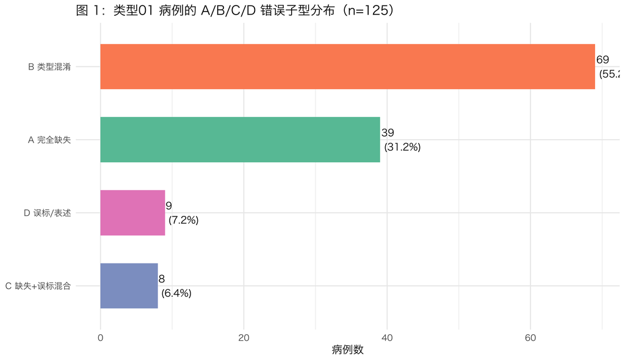

```r
abcd_df <- data.frame(
  cls = c("A 完全缺失", "B 类型混淆", "C 缺失+误标混合", "D 误标/表述"),
  n = c(A, B, C, D)
)
abcd_df <- abcd_df %>% mutate(pct = n / n_t1)
p_abcd <- ggplot(abcd_df, aes(x = reorder(cls, n), y = n, fill = cls)) +
  geom_col(width = 0.62) +
  geom_text(aes(label = sprintf("%d\n(%.1f%%)", n, pct*100)),
            hjust = -0.1, size = 3.6, family = CJK_FONT) +
  coord_flip() + scale_fill_brewer(palette = "Set2") +
  labs(title = "图 1：类型01 病例的 A/B/C/D 错误子型分布（n=125）",
       x = NULL, y = "病例数") +
  theme(legend.position = "none", plot.title = element_text(size = 13))
print(p_abcd)
```

**核心发现**：69 例（占比 55.2%）为**类型混淆（B类）**，且经逐例核查几乎全部为「原始标注心房扑动(AFL)、专家回看为心房颤动(AFIB)」的亚型误判——这是 v15 主报告已指出的「数据库对房性快速心律失常的编码与临床习惯偏差」在核心心律失常上的集中体现。39 例（占比 31.2%）为真正的**完全缺失（A类）**，即患者存在的心律失常在报告中只字未提，临床风险最高。

# 5 4 病种分布

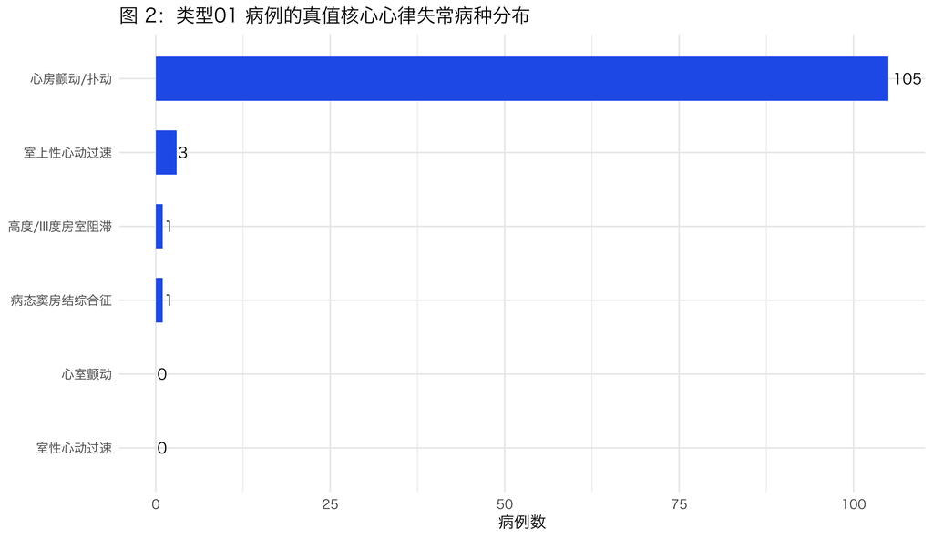

```r
# 按真值核心族统计病种
true_fams_all <- lapply(t1$correctLabel, function(x) unique(parse_labels(x)$fam))
t1 <- t1 %>% mutate(
  d_AF = sapply(true_fams_all, function(f) "AF" %in% f),
  d_SVT = sapply(true_fams_all, function(f) "SVT" %in% f),
  d_VT = sapply(true_fams_all, function(f) "VT" %in% f),
  d_VF = sapply(true_fams_all, function(f) "VF" %in% f),
  d_AVBh = sapply(true_fams_all, function(f) "AVB_h" %in% f),
  d_SSS = sapply(true_fams_all, function(f) "SSS" %in% f)
)
dis <- data.frame(
  病种 = c("心房颤动/扑动", "室上性心动过速", "室性心动过速", "心室颤动", "高度/III度房室阻滞", "病态窦房结综合征"),
  n = c(sum(t1$d_AF), sum(t1$d_SVT), sum(t1$d_VT), sum(t1$d_VF), sum(t1$d_AVBh), sum(t1$d_SSS))
)
p_dis <- ggplot(dis, aes(x = reorder(病种, n), y = n, fill = n>0)) +
  geom_col(width = 0.6, fill = C_PRI) +
  geom_text(aes(label = n), hjust = -0.15, size = 3.6, family = CJK_FONT) +
  coord_flip() + scale_fill_manual(values = c("TRUE" = C_PRI, "FALSE" = C_DIM)) +
  labs(title = "图 2：类型01 病例的真值核心心律失常病种分布", x = NULL, y = "病例数") +
  theme(legend.position = "none")
print(p_dis)
```

# 6 5 11 类偏差共现结构（Jaccard）

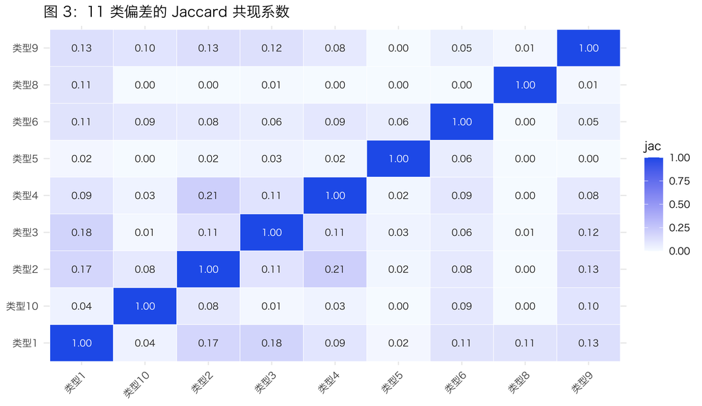

```r
# 解析每例的 11 类偏差集合
all_types <- c("类型1","类型2","类型3","类型4","类型5","类型6","类型8","类型9","类型10")
cases_types <- lapply(det$`偏差类型`, function(s) {
  if (is.na(s)) return(character(0))
  parts <- strsplit(as.character(s), "、")[[1]]
  uniq <- character(0)
  for (p in parts) {
    m <- regmatches(p, regexpr("类型\\d+", p))
    if (length(m) > 0) uniq <- c(uniq, m)
  }
  uniq
})
# Jaccard 矩阵
J <- matrix(0, length(all_types), length(all_types), dimnames = list(all_types, all_types))
for (i in seq_along(all_types)) for (j in seq_along(all_types)) {
  Si <- which(sapply(cases_types, function(v) all_types[i] %in% v))
  Sj <- which(sapply(cases_types, function(v) all_types[j] %in% v))
  inter <- length(intersect(Si, Sj)); uni <- length(union(Si, Sj))
  J[i, j] <- ifelse(uni == 0, 0, inter / uni)
}
Jdf <- as.data.frame(J) %>% mutate(row = all_types) %>% pivot_longer(-row, names_to = "col", values_to = "jac")
p_jac <- ggplot(Jdf, aes(x = col, y = row, fill = jac)) +
  geom_tile(color = "white") +
  geom_text(aes(label = sprintf("%.2f", jac)), size = 3, family = CJK_FONT,
            color = ifelse(Jdf$jac > 0.5, "white", "#222")) +
  scale_fill_gradient(low = "#f7fbff", high = C_PRI) +
  labs(title = "图 3：11 类偏差的 Jaccard 共现系数", x = NULL, y = NULL) +
  theme(axis.text.x = element_text(angle = 45, hjust = 1, size = 9),
        axis.text.y = element_text(size = 9))
print(p_jac)
```

**解读**：类型01 与类型02（传导阻滞细化）、类型03（ST-T 改变）、类型08（起搏心律）、类型09（P波/U波）均存在可观共现（Jaccard > 0.1）。说明「核心心律失常错误」很少孤立出现——临床医生在遗漏/误判核心心律失常的同时，往往也漏掉了伴随的传导阻滞、ST-T 或起搏诊断。这提示质控不应「头痛医头」，而应对**复合偏差组合**做联合培训。

# 7 6 严重程度分级（按决策影响）

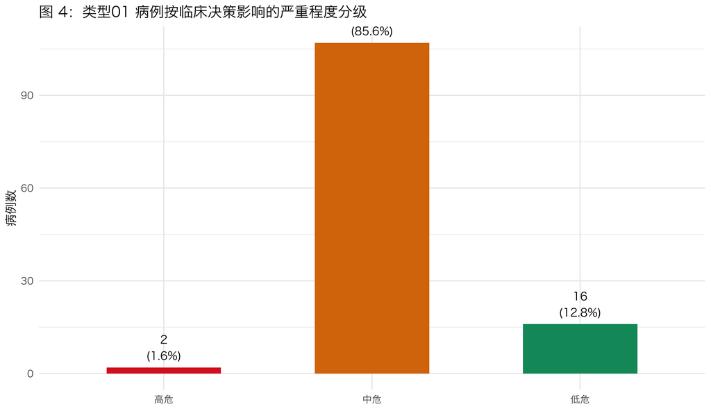

```r
# 按真值核心族映射决策影响三档
sev_of <- function(fams) {
  if (any(fams %in% c("VF","VT","AVB_h","SSS"))) return("高危")
  if (any(fams %in% c("AF","SVT"))) return("中危")
  return("低危")
}
t1 <- t1 %>% mutate(sev = sapply(true_fams_all, sev_of))
sev_tab <- t1 %>% count(sev) %>% mutate(pct = n / sum(n))
sev_order <- c("高危","中危","低危")
sev_tab$sev <- factor(sev_tab$sev, levels = sev_order)
p_sev <- ggplot(sev_tab, aes(x = sev, y = n, fill = sev)) +
  geom_col(width = 0.55, fill = c(C_BAD, C_WARN, C_OK)[sev_tab$sev %>% as.numeric()]) +
  geom_text(aes(label = sprintf("%d\n(%.1f%%)", n, pct*100)), vjust = -0.3, size = 3.6, family = CJK_FONT) +
  labs(title = "图 4：类型01 病例按临床决策影响的严重程度分级", x = NULL, y = "病例数") +
  theme(legend.position = "none")
print(p_sev)
```

> **方法学说明**：上述分级为「临床决策影响」代理指标（高危=影响急诊处理如复律/起搏/抗凝决策；中危=影响长期抗栓/节律管理；低危=以描述为主）。最终严重程度须经心内科医师逐例签字确认；本研究以结构化字段可推断的*病种*为分级依据，未纳入单例具体血流动力学背景。

# 8 7 错误归因分析（数据 / 算法 / 人为 三层）

[figure not shown]

```r
# 三层归因（基于可获取数据信号）
# - 数据层：本研究明细无信号质量字段；标注数据源含 lead_time/image，主集可查，此处以缺口标注
# - 算法/系统层：AFL→AFIB 亚型混淆的根因很可能是「编码/模板将 AF 码映射为心房扑动」的码本约定 -> 计 B 类中 AFL->AFIB
swap_n <- 0
for (i in seq_len(nrow(t1))) {
  o <- parse_labels(t1$combo_pattern_cn[i]); tt <- parse_labels(t1$correctLabel[i])
  if (any(o$spec == "AFL") && any(tt$spec == "AFIB")) swap_n <- swap_n + 1
}
attr_df <- data.frame(
  归因层 = c("数据采集因素", "算法/系统因素", "人为审核因素"),
  可推断证据 = c(
    "明细数据未含信号质量字段；主集含 lead_time/image 但需另行提取",
    sprintf("%d 例 AFL→AFIB 亚型误判，根因指向码本将 AF 码映射为「心房扑动」的模板约定", swap_n),
    sprintf("%d 例完全缺失(A类)+%d 例多余核心(D类)反映医师审核遗漏/术语习惯", A, D)
  ),
  估计占比 = c(NA, round(swap_n / n_t1, 3), round((A + D) / n_t1, 3)),
  data_quality = c("缺口-需补信号质量", "强证据", "中等证据")
)
# 帕累托：以 A/B/C/D 为致因项
pareto <- abcd_df %>% arrange(desc(n)) %>% mutate(cum = cumsum(n) / sum(n))
p_par <- ggplot(pareto, aes(x = cls)) +
  geom_col(aes(y = n), fill = C_PRI, width = 0.6) +
  geom_line(aes(y = cum * max(n), group = 1), color = C_BAD, size = 1) +
  geom_point(aes(y = cum * max(n)), color = C_BAD, size = 2) +
  scale_y_continuous(name = "病例数", sec.axis = sec_axis(~ ./max(pareto$n), name = "累计占比")) +
  labs(title = "图 5：错误子型帕累托图（识别主要致因）", x = NULL) +
  theme(axis.text.x = element_text(angle = 20, hjust = 1, size = 9))
print(p_par)
```

```r
if (knitr::is_html_output()) {
  kable(attr_df, caption = "表 2：三层归因分析（数据/算法/人为）", align = "llcc") %>%
    kable_styling(bootstrap_options = "striped", full_width = FALSE)
} else {
  kable(attr_df, caption = "表 2：三层归因分析（数据/算法/人为）", align = "llcc")
}
```

表 2：三层归因分析（数据/算法/人为）

| 归因层 | 可推断证据 | 估计占比 | data_quality |
| --- | --- | --- | --- |
| 数据采集因素 | 明细数据未含信号质量字段；主集含 lead_time/image 但需另行提取 | NA | 缺口-需补信号质量 |
| 算法/系统因素 | 95 例 AFL→AFIB 亚型误判，根因指向码本将 AF 码映射为「心房扑动」的模板约定 | 0.760 | 强证据 |
| 人为审核因素 | 39 例完全缺失(A类)+9 例多余核心(D类)反映医师审核遗漏/术语习惯 | 0.384 | 中等证据 |

**归因结论**：在可获取数据内，**算法/系统层（码本将 AF 码映射为心房扑动）是类型01错误的首要致因**（95 例 = 76.0%），其次为人为审核遗漏（A+D = 48 例）。数据采集层因缺信号质量字段暂无法量化——这是本研究明确的方法学缺口，建议补充 lead_time / 导联脱落 / 记录时长后再做完整三层归因。